# RStudio Exercise 5

```r
date()
```

```
## [1] "Mon Dec  6 00:45:17 2021"
```

### The Human dataset - an overview

The human dataset contains country-specific indicators relating to the Human Development Index (HDI), provided by the United Nations Development Programme. The index measures achievements in dimensions of human development such as health and longevity, education and standard of living.

Variables included in this exercise indicate the ratio of women to men in secondary education and labour force, as well as expected length of education and life. Variables also include Gross National Income as a measure of standard of living, and maternal mortality and adolescent birth rate as measures of the level of health care provided to young women.

```r
# reading the human data from my data folder
human <- read.csv("./data/human.csv", stringsAsFactors = F, row.names = 1)
# exploring the data structure
head(human)
```

```
##              EduRatio  LabRatio EducExp LifeExp   GNI Matmort AdolBirthRt
## Norway      1.0072389 0.8908297    17.5    81.6 64992       4         7.8
## Australia   0.9968288 0.8189415    20.2    82.4 42261       6        12.1
## Switzerland 0.9834369 0.8251001    15.8    83.0 56431       6         1.9
## Denmark     0.9886128 0.8840361    18.7    80.2 44025       5         5.1
## Netherlands 0.9690608 0.8286119    17.9    81.6 45435       6         6.2
## Germany     0.9927835 0.8072289    16.5    80.9 43919       7         3.8
##             ParlRep
## Norway         39.6
## Australia      30.5
## Switzerland    28.5
## Denmark        38.0
## Netherlands    36.9
## Germany        36.9
```

```r
summary(human)
```

```
##     EduRatio         LabRatio         EducExp         LifeExp
##  Min.   :0.1717   Min.   :0.1857   Min.   : 5.40   Min.   :49.00
##  1st Qu.:0.7264   1st Qu.:0.5984   1st Qu.:11.25   1st Qu.:66.30
##  Median :0.9375   Median :0.7535   Median :13.50   Median :74.20
##  Mean   :0.8529   Mean   :0.7074   Mean   :13.18   Mean   :71.65
##  3rd Qu.:0.9968   3rd Qu.:0.8535   3rd Qu.:15.20   3rd Qu.:77.25
##  Max.   :1.4967   Max.   :1.0380   Max.   :20.20   Max.   :83.50
##       GNI            Matmort        AdolBirthRt        ParlRep
##  Min.   :   581   Min.   :   1.0   Min.   :  0.60   Min.   : 0.00
##  1st Qu.:  4198   1st Qu.:  11.5   1st Qu.: 12.65   1st Qu.:12.40
##  Median : 12040   Median :  49.0   Median : 33.60   Median :19.30
##  Mean   : 17628   Mean   : 149.1   Mean   : 47.16   Mean   :20.91
##  3rd Qu.: 24512   3rd Qu.: 190.0   3rd Qu.: 71.95   3rd Qu.:27.95
##  Max.   :123124   Max.   :1100.0   Max.   :204.80   Max.   :57.50
```

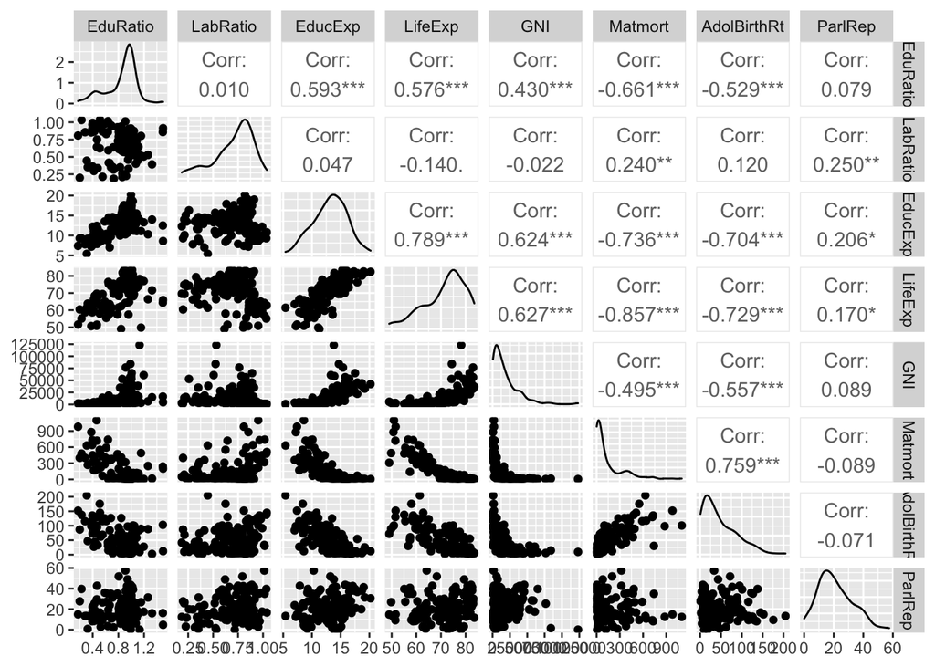

```r
# plotting pairs
library(GGally)
ggpairs(human)
```

Below is a corrplot diagram of the correlation relations between variables. Based on the data, it is interesting to note that parliament representation does not seem to be particularly strongly correlated with anything. At least from the corrplot diagram, no strong correlation can be discerned (share of females in parliament is moderately correlated with labour force ratio, expected length of education and life expectancy). Neither does labour force ratio seem to be strongly correlated with anything.

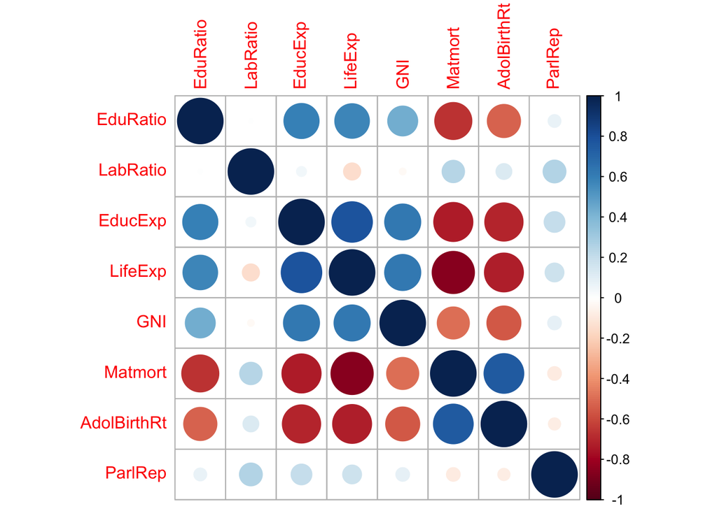

```r
# drawing a corrplot
library(corrplot)
cor(human) %>% corrplot()
```

### Performing principal component analysis (PCA)

First, I will perform a principal component analysis (PCA) on the *non-standardized* human data, as instructed in the exercise. The variability captured by the principal components is given in the printout of values below. The plot highlights the impact of the Gross National Income (GNI) variable as this was the one variable containing the largest absolute numbers (maximum values over 100 times larger than in any other variable).

```r
# perform principal component analysis (with the SVD method) on the human dataset in its *non-standardized* form
pca_human <- prcomp(human)
# exploring the variability captured by the principal components
summary(pca_human)$importance[2,]
```

```
##    PC1    PC2    PC3    PC4    PC5    PC6    PC7    PC8
## 0.9999 0.0001 0.0000 0.0000 0.0000 0.0000 0.0000 0.0000
```

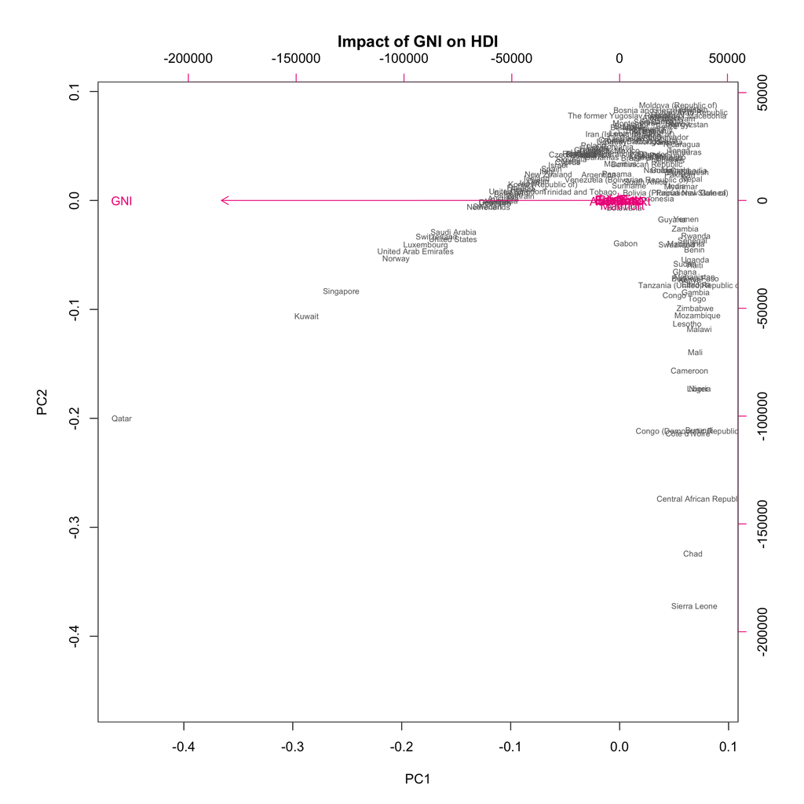

```r
# draw a biplot of the principal component representation and the original variables
biplot(pca_human, choices = 1:2, cex = c(0.6, 0.9), col = c("grey40", "deeppink2"), main = "Impact of GNI on HDI")
```

Now, I will redo the PCA analysis with standardized variables.

```r
# standardize variables
human_std <- scale(human)
# perform principal component analysis (with the SVD method) on the human dataset in its *standardized* form
pca_human_std <- prcomp(human_std)
# exploring the variability captured by the principal components
s <- summary(pca_human_std)$importance[2,]
s
```

```
##     PC1     PC2     PC3     PC4     PC5     PC6     PC7     PC8
## 0.53605 0.16237 0.09571 0.07583 0.05477 0.03595 0.02634 0.01298
```

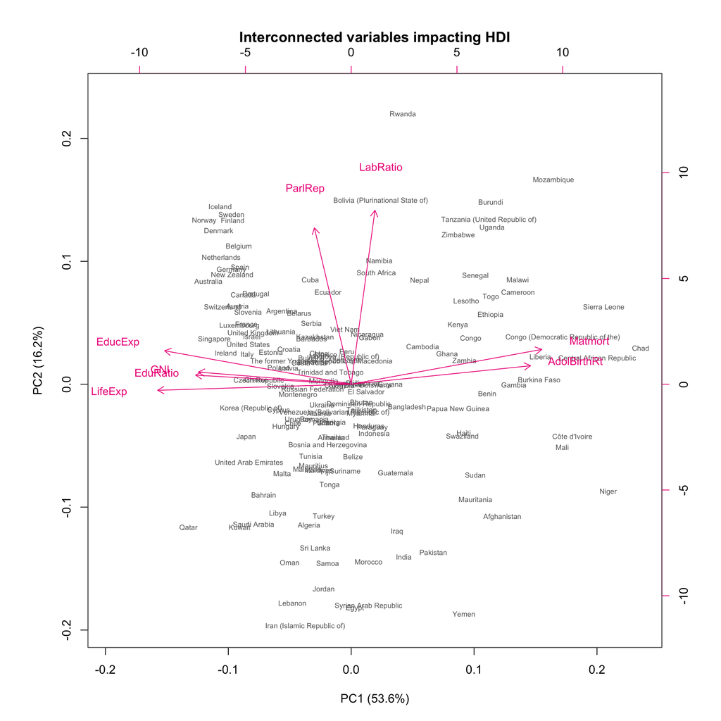

```r
# save rounded percetanges of variance captured by each PC (to be used as axis labels)
pca_pr <- round(s*100, digits = 1)
# create object pc_lab (to be used as axis labels)
pc_lab <- paste0(names(pca_pr), " (", pca_pr, "%)")
# draw a biplot of the principal component representation and the original variables
biplot(pca_human_std, choices = 1:2, cex = c(0.6, 0.9), col = c("grey40", "deeppink2"), xlab = pc_lab[1], ylab = pc_lab[2], main = "Interconnected variables impacting HDI")
```

As was seen above, the first plot drawn from the non-standardized version was extremely hard to read as almost all results in the scatter plot were pushed into the upright corner into a really crowded space. Because of the high absolute values reported in the GNI variable, that is about the only arrow whose direction is visible in the first plot; I can’t even tell if there are any arrows pointing in any other direction (I suppose the arrows of ParlRep and LabRatio are pointing upwards, but they are at least not properly visible.)

The Human Development Index (HDI) is a summary measure of average achievement in key dimensions of human development: a long and healthy life, being knowledgeable and have a decent standard of living according to the [UNDP](http://hdr.undp.org/en/content/human-development-index-hdi).

From the latter plot we can discern three groups of variables that seem to influence the HDI index value in different ways. Life expectancy, maternal mortality and adolescent birth rate are all related to living a long and healthy life. Life expectancy is negatively correlated with maternal mortality and adolescence birth rate, and so the arrows here pull results in opposite directions.

The proportion of women in labour force and parliament (visible as arrows pointing upwards) can be interpreted as variables measuring women’s possibilities to participate in and impact society. The proportion of women in parliament is moderately correlated with the proportion of women in the labour force.

Interestingly, the ratio of women to men in secondary education is more strongly related to life expectancy than to the proportion of women in parliament or the ratio of women to men in the labour force. Being knowledgeable seems to be more strongly correlated with being able to live a long and healthy life than the ability to participate in working life and national politics.

### Balancing national income and gender equality - interpreting the first two principal component dimensions of the PCA

The vertical y axis is also an interesting one, although initially harder to label. I speculated over wheter it was a conservative-liberal axis or progressive-reactionary axis, before I concluded that the y axis is all about gender equality. Let me explain why.

The angle between a variable and a PC axis can be interpret as the correlation between the two. In the case of the x axis, the difference in angle is minimal between the variables at each horizontal end. As the difference in angle between the ParlRep and LabRatio variables and the y axis are almost as small (although significantly larger), one could understand the y axis as an axis reflecting equality between women and men (in politics and the workforce), placing Rwanda at the top and hard-line Arab states at the bottom. (Rwanda’s top placement might come in as a surprise for somebody, but the power balance between men and women in Rwanda, and attitudes and approaches chosen by Rwandian women, have been elaborated in some media articles for example [here](https://www.npr.org/sections/goatsandsoda/2018/01/10/577018509/rwanda-ranks-in-the-top-5-for-gender-equity-do-its-teen-girls-agree).)

In principal component analyses, the first principal component captures the maximum amount of variance from the features of the original data. In this instance, the PC1 (relating to life expectancy and health issues) explains just over half of the variance. But the gender equality aspects relating to female representation in the labour force and national politics account for only a sixth of the variance between countries. (Note how one single variable, the GNI explained 99 per cent of the variation in the erroneous first plot.)

A note on the side: What the plots - and the data - has not said anything about is the division of income and wealth distribution within countries. Attempts to quantify inequality have at various times been made using for instance the Gini coefficient, although this measurement unit has shortcomings of its own (it does not for instance take into account the effect of income redistributions, differences in living expenses between countries as well as distribution of wealth).

### Exploring tea drinking habits

The tea dataset of the FactoMineR package includes 300 observations of 36 variables relating to tea drinking habits. Most variables are factors with 2 levels (i.e. binaries), but some variables include factors with more levels. Initially, I will visualise the data by drawing histograms of six of the most interesting variables. I will then conduct a Multiple Correspondence Analysis on the tea data and offer an interpretation the results of the MCA and draw a variable biplot.

```r
# loading the tea dataset
library(FactoMineR) #I installed Factominer before writing this code
library(ggplot2)
library(dplyr)
library(tidyr)
data("tea")
# exploring the tea dataset
str(tea)
```

```
## 'data.frame':    300 obs. of  36 variables:
##  $ breakfast       : Factor w/ 2 levels "breakfast","Not.breakfast": 1 1 2 2 1 2 1 2 1 1 ...
##  $ tea.time        : Factor w/ 2 levels "Not.tea time",..: 1 1 2 1 1 1 2 2 2 1 ...
##  $ evening         : Factor w/ 2 levels "evening","Not.evening": 2 2 1 2 1 2 2 1 2 1 ...
##  $ lunch           : Factor w/ 2 levels "lunch","Not.lunch": 2 2 2 2 2 2 2 2 2 2 ...
##  $ dinner          : Factor w/ 2 levels "dinner","Not.dinner": 2 2 1 1 2 1 2 2 2 2 ...
##  $ always          : Factor w/ 2 levels "always","Not.always": 2 2 2 2 1 2 2 2 2 2 ...
##  $ home            : Factor w/ 2 levels "home","Not.home": 1 1 1 1 1 1 1 1 1 1 ...
##  $ work            : Factor w/ 2 levels "Not.work","work": 1 1 2 1 1 1 1 1 1 1 ...
##  $ tearoom         : Factor w/ 2 levels "Not.tearoom",..: 1 1 1 1 1 1 1 1 1 2 ...
##  $ friends         : Factor w/ 2 levels "friends","Not.friends": 2 2 1 2 2 2 1 2 2 2 ...
##  $ resto           : Factor w/ 2 levels "Not.resto","resto": 1 1 2 1 1 1 1 1 1 1 ...
##  $ pub             : Factor w/ 2 levels "Not.pub","pub": 1 1 1 1 1 1 1 1 1 1 ...
##  $ Tea             : Factor w/ 3 levels "black","Earl Grey",..: 1 1 2 2 2 2 2 1 2 1 ...
##  $ How             : Factor w/ 4 levels "alone","lemon",..: 1 3 1 1 1 1 1 3 3 1 ...
```

[output cut: 22 more lines]

```r
summary(tea)
```

```
##          breakfast           tea.time          evening          lunch
##  breakfast    :144   Not.tea time:131   evening    :103   lunch    : 44
##  Not.breakfast:156   tea time    :169   Not.evening:197   Not.lunch:256
##
##
##
##
##
##         dinner           always          home           work
##  dinner    : 21   always    :103   home    :291   Not.work:213
##  Not.dinner:279   Not.always:197   Not.home:  9   work    : 87
##
##
##
##
##
##         tearoom           friends          resto          pub
##  Not.tearoom:242   friends    :196   Not.resto:221   Not.pub:237
##  tearoom    : 58   Not.friends:104   resto    : 79   pub    : 63
##
##
##
##
##
##         Tea         How           sugar                     how
##  black    : 74   alone:195   No.sugar:155   tea bag           :170
##  Earl Grey:193   lemon: 33   sugar   :145   tea bag+unpackaged: 94
##  green    : 33   milk : 63                  unpackaged        : 36
##                  other:  9
##
##
##
##                   where                 price          age        sex
##  chain store         :192   p_branded      : 95   Min.   :15.00   F:178
##  chain store+tea shop: 78   p_cheap        :  7   1st Qu.:23.00   M:122
##  tea shop            : 30   p_private label: 21   Median :32.00
##                             p_unknown      : 12   Mean   :37.05
##                             p_upscale      : 53   3rd Qu.:48.00
##                             p_variable     :112   Max.   :90.00
##
```

[output cut: 25 more lines]

```
##  feminine    :129   Not.sophisticated: 85   No.slimming:255   exciting   :116
##  Not.feminine:171   sophisticated    :215   slimming   : 45   No.exciting:184
##
##
##
##
##
##         relaxing              effect.on.health
##  No.relaxing:113   effect on health   : 66
##  relaxing   :187   No.effect on health:234
##
##
##
##
##
```

```r
?tea
dim(tea)
```

```
## [1] 300  36
```

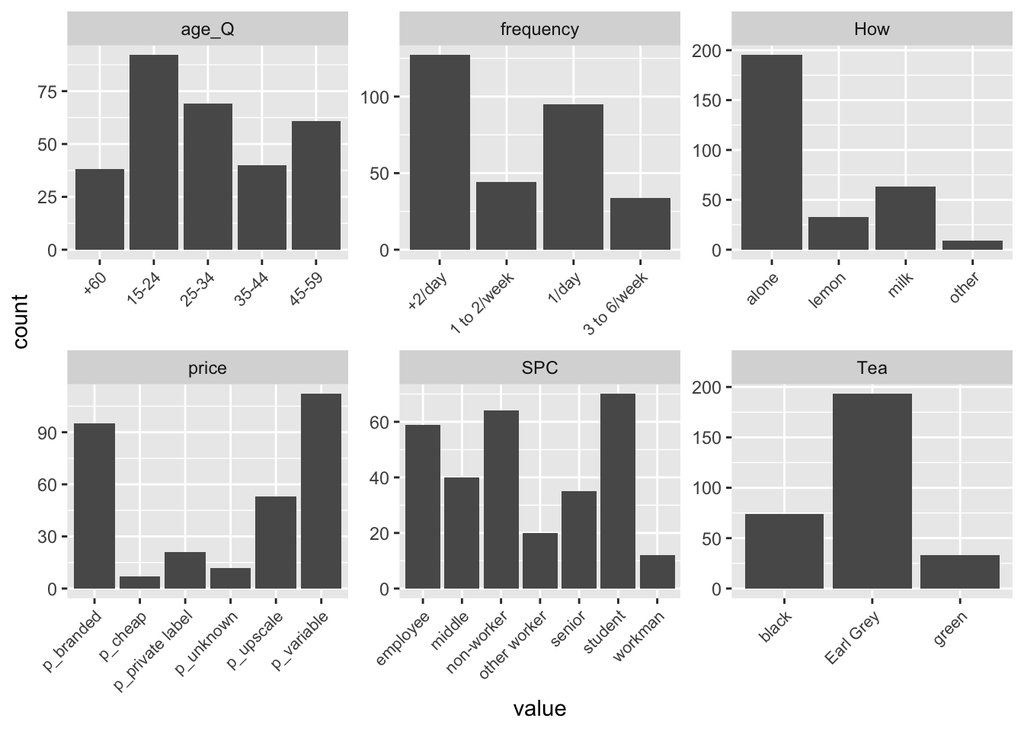

```r
# moving on to visualization. I choose to visualize six of the variables that I find most interesting.
keep_columns <- c("age_Q","frequency","How","price","SPC","Tea")
tea_visu <- select(tea, one_of(keep_columns))
gather(tea_visu) %>% ggplot(aes(value)) + facet_wrap("key", scales = "free") + geom_bar() + theme(axis.text.x = element_text(angle = 45, hjust = 1, size = 8))
```

```r
# conducting the Multiple Correspondence Analysis. I continue with my selection of six interesting variables.
mca <- MCA(tea_visu, graph = FALSE)
summary(mca)
```

```
##
## Call:
## MCA(X = tea_visu, graph = FALSE)
##
##
## Eigenvalues
##                        Dim.1   Dim.2   Dim.3   Dim.4   Dim.5   Dim.6   Dim.7
## Variance               0.350   0.292   0.234   0.214   0.206   0.198   0.189
## % of var.              9.127   7.610   6.092   5.588   5.386   5.172   4.926
## Cumulative % of var.   9.127  16.737  22.830  28.417  33.803  38.975  43.901
##                        Dim.8   Dim.9  Dim.10  Dim.11  Dim.12  Dim.13  Dim.14
## Variance               0.181   0.180   0.178   0.170   0.166   0.152   0.149
## % of var.              4.730   4.705   4.636   4.431   4.334   3.977   3.897
## Cumulative % of var.  48.631  53.336  57.972  62.403  66.737  70.714  74.611
##                       Dim.15  Dim.16  Dim.17  Dim.18  Dim.19  Dim.20  Dim.21
## Variance               0.145   0.140   0.134   0.123   0.113   0.109   0.108
## % of var.              3.789   3.663   3.484   3.222   2.960   2.849   2.813
## Cumulative % of var.  78.400  82.064  85.547  88.769  91.729  94.577  97.390
##                       Dim.22  Dim.23
## Variance               0.055   0.046
## % of var.              1.423   1.188
## Cumulative % of var.  98.812 100.000
##
## Individuals (the 10 first)
##                Dim.1    ctr   cos2    Dim.2    ctr   cos2    Dim.3    ctr
## 1           |  0.239  0.054  0.008 |  1.146  1.501  0.184 |  0.579  0.478
## 2           |  0.461  0.202  0.060 |  0.798  0.727  0.181 |  0.313  0.140
## 3           |  0.025  0.001  0.000 |  0.459  0.241  0.057 |  0.211  0.063
## 4           | -0.847  0.684  0.411 | -0.364  0.151  0.076 |  0.155  0.034
## 5           | -0.125  0.015  0.008 |  0.193  0.042  0.018 | -0.049  0.003
## 6           | -0.973  0.901  0.257 | -0.391  0.175  0.042 |  0.122  0.021
## 7           |  0.055  0.003  0.001 |  0.531  0.322  0.069 |  0.818  0.955
## 8           |  0.401  0.153  0.035 |  0.702  0.563  0.108 |  1.012  1.462
## 9           |  0.454  0.196  0.051 |  0.693  0.549  0.118 |  0.767  0.839
## 10          |  0.680  0.441  0.117 |  0.520  0.309  0.069 |  0.911  1.185
##               cos2
## 1            0.047 |
## 2            0.028 |
## 3            0.012 |
## 4            0.014 |
```

[output cut: 24 more lines]

```
## +60         |  -0.349   1.099   0.018  -2.296 |
## 1/day       |  -0.644   9.372   0.192  -7.580 |
## 1 to 2/week |   0.576   3.468   0.057   4.127 |
## +2/day      |   0.175   0.926   0.023   2.594 |
## 3 to 6/week |   0.400   1.297   0.020   2.475 |
## alone       |  -0.012   0.006   0.000  -0.271 |
##
## Categorical variables (eta2)
##               Dim.1 Dim.2 Dim.3
## age_Q       | 0.767 0.732 0.267 |
## frequency   | 0.027 0.097 0.211 |
## How         | 0.156 0.074 0.139 |
## price       | 0.162 0.097 0.207 |
## SPC         | 0.677 0.745 0.327 |
## Tea         | 0.310 0.005 0.250 |
```

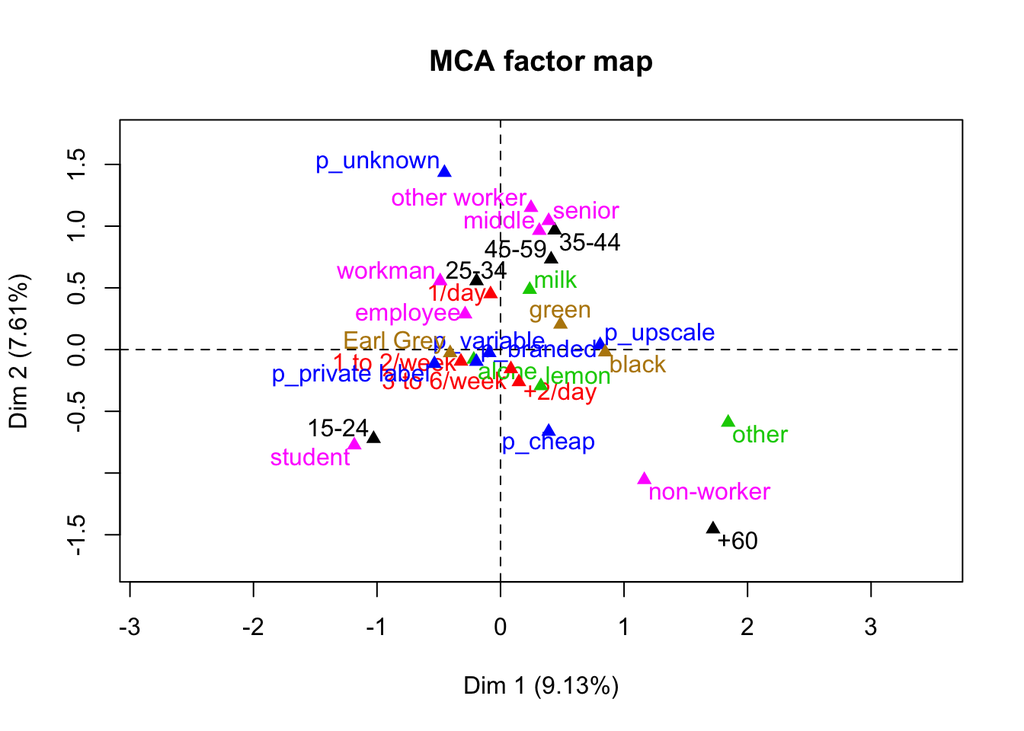

```r
plot(mca, invisible=c("ind"), habillage = "quali", graph.type = "classic")
```

As the distance between variable categories in a MCA provides a measure of their similarity, this gives me some hints as to how to interpret tea drinking habits of different population groups. The pink colour indicates occupation, black indicates age, blue indicates tea brand, red indicates tea drinking frequency, brown indicates kind of tea (green or black or other) and green indicates ways of drinking tea (e.g. with milk or lemon).

It’s worth noting, that the two dimensions plotted in the MCA factor map do not account for a significant amount of the variation - in fact, less than ten per cent each. That is, there are other variables who jointly explain much more of the variation in tea drinking habits.